# Raining 3s in the NBA

# Big Picture

The National Basketball Association (NBA) league is considered one of the most popular sports in the US and the rest of the world. The business surrounding NBA is worth billions of dollars, and a significant amount of money is channeled toward scouting and paying elite players. All sports organizations usually incur a hefty amount of finances to acquire a player who may end up underperforming. Hence, there is an urgent need for a proactive approach to selecting players to avoid unnecessary financial loss. Luckily, the NBA is known for the vast amount of data harnessed for each player, team, season, and game. Therefore, we will leverage the available data and transform it into useful insights that will support critical decisions related to player signings and the allocation of salaries and incentives based on performance. While there are different metrics to gauge player performance, our analysis focuses on scoring, in particular, the 3-point scoring, because it’s the most critical factor from the primary players for any team as well as the NBA’s favorable style (Nguyen et al., 2021).

## The Boston Celtics Revamp

After losing to the Golden State Warriors in the NBA Finals. The manager of the Boston Celtics wants to create a new offense for the team. Inspired by the Warrior’s offense and their legacy as repeating NBA champions, the manager decides to look into 3 point shooting as a stat to base his offense around. Which players should he find and is 3 point shooting really that correlated to success?

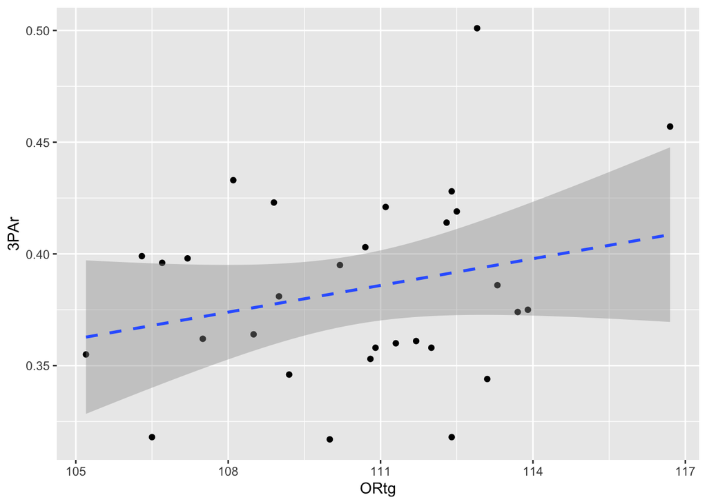

Out of the thirty teams in the NBA, there seems to be a positive correlation with the number of 3 pointers attempted. This is a good indication of what makes a good offense. In terms of basketball, this allows the offense to space the floor and create more opportunities for players to score inside and outside the 3 point line.

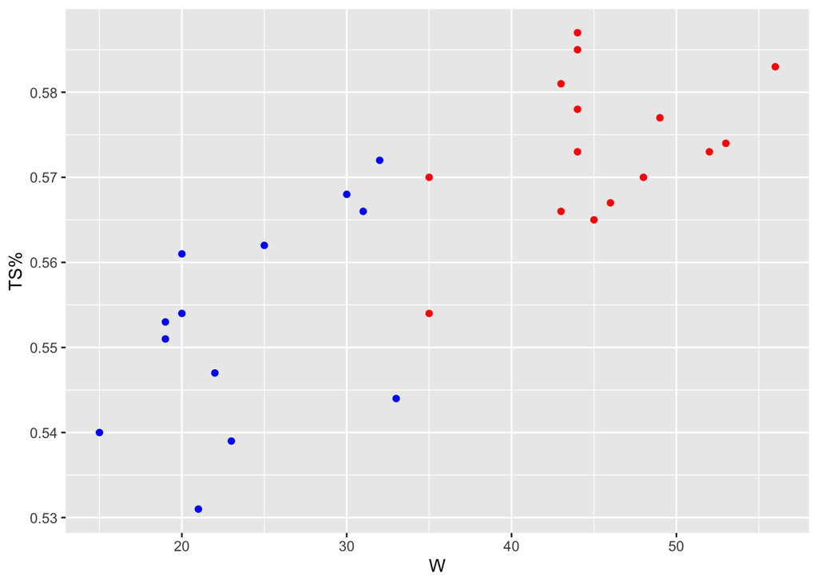

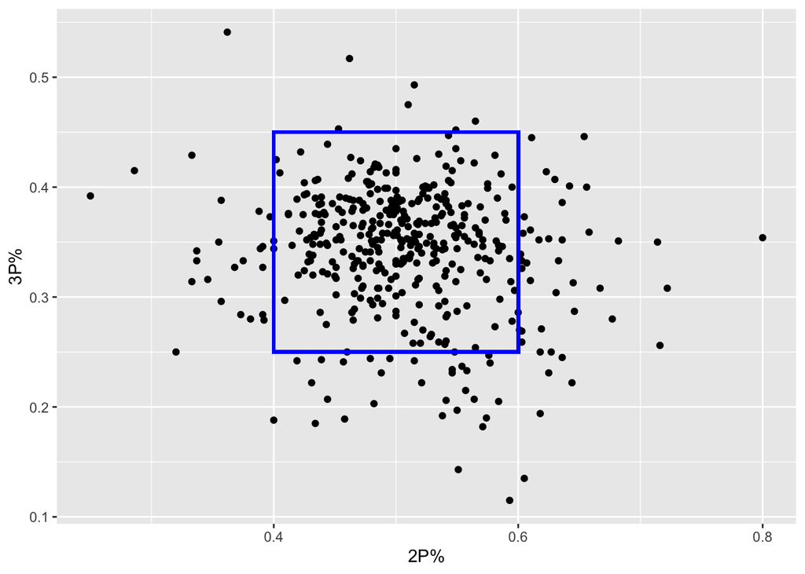

Now that the Celtics have seen that there is a relationship between winning and shooting three point field goals. Their next step is to find players that can be either molded into great three point shooters or already are shooting threes at a high level. In the plot above we see that the majority of players who make their two point field goals at a mean rate of about 50% also tend to have a consistent three point percentage of 0.35. The Celtics can use this as a basic criteria for their selection of players.

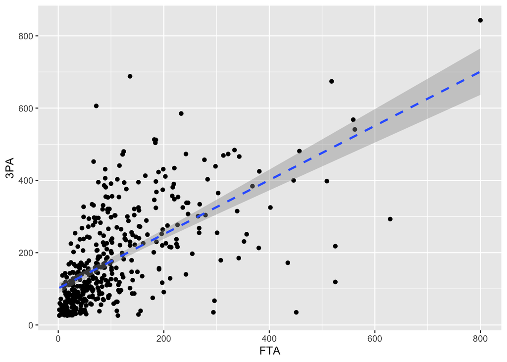

In order to find players that fit this type of play style, the Celtics also looked at free throws attempted. Surprsingly there seems to be positive correlation between the number of free throws taken and the number of three points attempted. This could mean that players that attack the paint tend to also shoot more three pointers. Typically player that fit in this slasher type of role are not considered shooters, but this suggests that their volume of three point attempts could mean they could potentially be good options for three point shots as well.

The Boston Celtics decide to find more statistics and correlations to find potential great three points shooters. To see more please proceed to the Analysis Page!

Heres an interactive to compare some of the stats for teams! [INTERACTIVE LINK](https://huyphan.shinyapps.io/example/)